# Improving Replicability of Neuroimaging Research

Simon Vandekar

# Definitions

**Replicability:** ability to obtain consistent results across independent studies with different data aimed at answering the same scientific question.

**Reproducibility:** ability to obtain the identical results across independent studies with the same dataset aimed at answering the exact same scientific question.

- Replicability is related to statistics, reproducibility is informatics

# Overview

- Replicability in neuroimaging
- Challenges to replicability
- Strategies to improve replicability
- Effect sizes

# Why effect sizes?

# Larger effect sizes cause better replicability

## “Parameters” versus “Estimates”

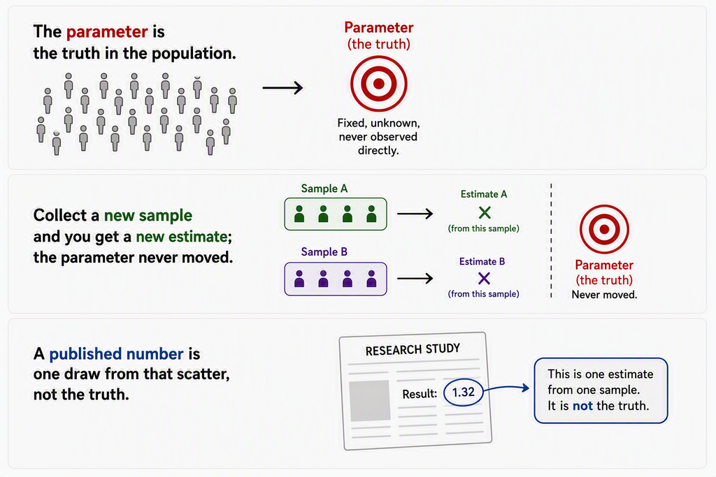

- Smaller samples give estimates that scatter farther from the parameter

## Biological effect sizes

- Governed by factors we cannot control
- Units are determined by the variables themselves
  - $\beta$ coefficients, odds ratios, relative risks

### Standardized effect sizes

- A unitless statistical index that summarizes the strength of an association
  - Cohen’s $d$, Pearson’s correlation, $R^2$, Cohen’s $f$, $\eta^2$
- Complimentary to reporting $p$-values and biological effect sizes

## Standardized effect size scale

- I will use effect sizes on the scale Cohen’s $f \in [0, \infty)$, realistically, $f<1$.
- Cohen (behavioral scientist) recommended standardized benchmarks
  - These are only recommendations

| Effect size | Cohen’s $f$ |
| --- | --- |
| Small | 0.10 |
| Medium | 0.25 |
| Large | 0.40 |

## Standardized effect size parameters drive replicability

Replicability (in statistics, a probability)

↑ ↑

Standardized effect size (e.g. Pearson's correlation)

↑ ↑

Study design

Underlying biological  
effect size (e.g. *β* coefficient)

Sample size

## Quiz: parameter/estimate? biological/standardized?

- Hippocampal volume difference (in mm³) between individuals with schizophrenia and healthy adults in all humans → **parameter**, **biological** – units mm³, and it is the unknown truth in the population
- ENIGMA reports $d = -0.46$ for hippocampal volume in schizophrenia from 4,568 scans → **estimate**, **standardized** – unitless, and computed from their particular sample
- Your study’s fitted slope of 0.8 mL of cortical volume lost per year of age → **estimate**, **biological** – mL/year units, but it came from your sample
- The correlation between amyloid PET SUVR and memory score you would get if you scanned everyone → **parameter**, **standardized** – unitless, but defined on the population, not a sample

Parameter vs. estimate is about *population vs. sample*; biological vs. standardized is about the *units*.

# Most neuroimaging studies are not replicable

**Unreliability of Biomarker Research in Psychiatry**

Vandekar, S., Zhang, P., Patel. P.K., Jefferson, A.L., Harrell, F. (*under review*)

## Over decade of evidence of low replicability

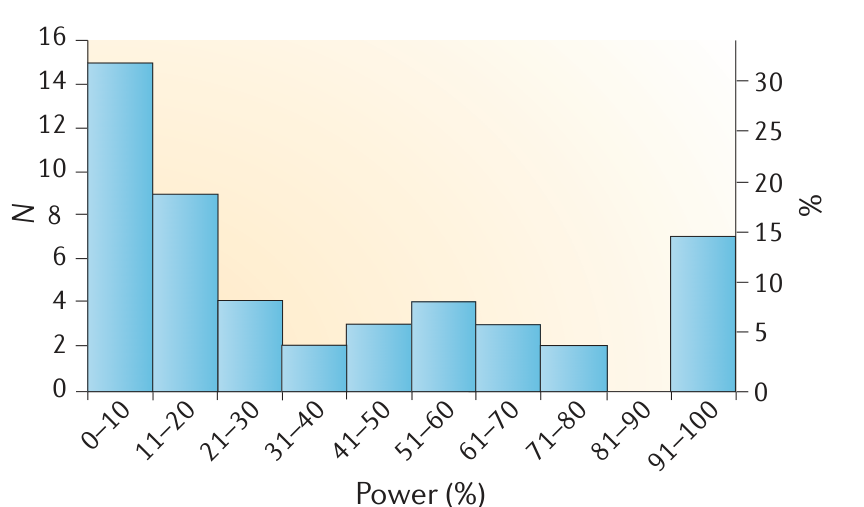

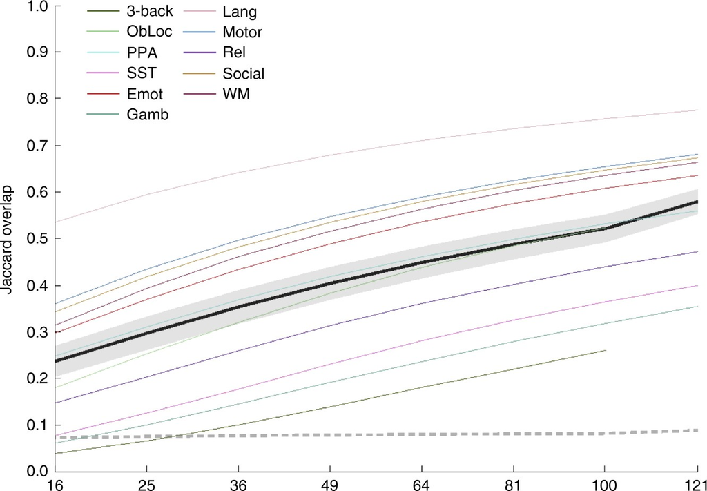

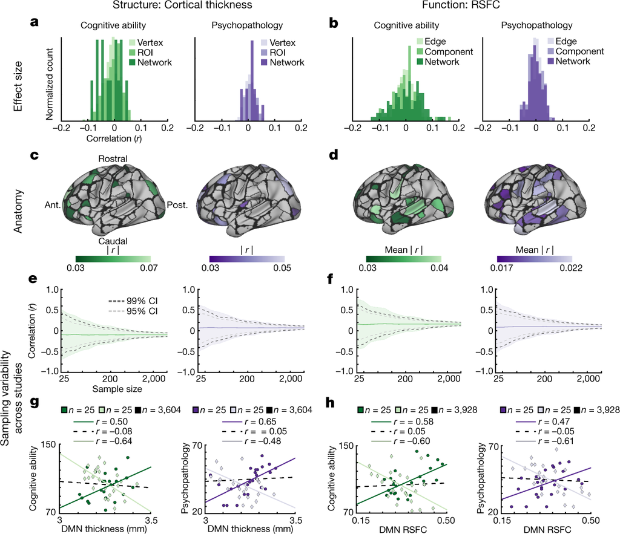

**Marek 2022, Fig. 1** — brain–phenotype correlations cluster near zero (median |*r*| = 0.01); at *N* = 25 the same effect can come out *r* = +0.5 or −0.6.

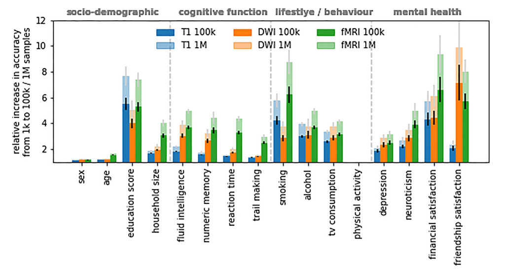

# Challenges to replicability in neuroimaging

- Inadequate sample sizes
- Multitude of analytic decisions
- Neglecting clinical information
- Misleading uncertainty quantification

## Inadequate sample sizes

- Neuroimaging samples are often under ~100

| Biomarker / association | Reported effect | Cohen's *f* | Sample | Original study | Failed replication |
| --- | --- | --- | --- | --- | --- |
| FDG-PET right anterior insula treatment-selection biomarker | Cohen's *f* = 0.80* | 0.80* | n = 38 primary analysis | McGrath 2013, [*JAMA Psychiatry*](https://doi.org/10.1001/jamapsychiatry.2013.143) | [Kelley 2021, prospective PET test](https://doi.org/10.1016/j.biopsych.2021.02.966) |
| fMRI cognitive-control connectivity → antidepressant response | d=1.14–1.37 | 0.57–0.685 | n = 40 Sertraline group | Tozzi 2020, [*Biological Psychiatry*](https://doi.org/10.1016/j.biopsych.2019.08.005) |  |
| EEG abnormality → antidepressant response | OR = 3.56 (escitalopram); OR = 2.76 (venlafaxine-XR) | 0.35; 0.31 | n = 622 per-protocol patients | Arns 2017, [*Clinical EEG and Neuroscience*](https://doi.org/10.1177/1550059415621435) | [Reveles Jensen, 2024](https://clinicalkey.com/#!/content/playContent/1-s2.0-S0924977X23007174) |
| rTMS → brain-function variability in schizophrenia | Local BOLD: F<sub>1,36</sub> = 5.83; MCD: F<sub>1,36</sub> = 32.57 | 0.40; 0.95 | n = 42 (active 19; sham 23) | Schifani 2025, [*Schizophrenia Bulletin*](https://doi.org/10.1093/schbul/sbae166) |  |

- Small samples are highly variable and lead to inaccurate published effect size estimates
- Power analyses using published effect size estimates from small studies justify small samples in grants

## Comparison to effect sizes we know

| Association / intervention | Reported effect | Cohen's *f* (estimate) | Evidence base |
| --- | --- | --- | --- |
| COVID-19 vaccine (BNT162b2) vs. placebo | efficacy 95% | 0.83 | Polack 2020, [*NEJM*](https://doi.org/10.1056/NEJMoa2034577) — n = 43,448 |
| Smoking → lung cancer (current vs. never) | RR = 8.96 | 0.60 | Gandini 2008, [*Int J Cancer*](https://doi.org/10.1002/ijc.23033) — 216 studies |
| Psilocybin-assisted therapy for depression | g = 0.84 | 0.42 | Florineth 2026, [*JAMA Netw Open*](https://doi.org/10.1001/jamanetworkopen.2025.54843) — 12 trials, n = 733 |
| Antidepressants vs. placebo | OR = 1.37–2.13 | 0.09–0.21 | Cipriani 2018, *Lancet* — 522 trials, n = 116,477 |
| GWAS: *FTO* (rs1558902) → BMI, largest common-variant effect | β = 0.082 SD/allele | 0.06 | Locke 2015, [*Nature*](https://doi.org/10.1038/nature14177) — n = 339,224 |
| ENIGMA: hippocampal volume in schizophrenia | d = −0.46 | 0.23 | van Erp 2016, [*Mol Psychiatry*](https://doi.org/10.1038/mp.2015.63) — n = 4,568 |
| ENIGMA: hippocampal volume in depression | d = −0.14 | 0.07 | Schmaal 2016, [*Mol Psychiatry*](https://doi.org/10.1038/mp.2015.69) — n = 8,927 |
| Brain-wide association — largest replicable | r = 0.16 | 0.16 | Marek 2022, [*Nature*](https://doi.org/10.1038/s41586-022-04492-9) — n ≈ 50,000 |
| Brain-wide association — median | r = 0.01 | 0.01 | Marek 2022, [*Nature*](https://doi.org/10.1038/s41586-022-04492-9) — n ≈ 50,000 |

Cohen’s benchmarks for $f$: 0.10 small, 0.25 medium, 0.40 large.

- Prespecified analyses in underpowered samples lead to inconclusive results
  - Effect size estimates are unstable
  - The CI is too wide to provide useful information
  - A nonsignificant $p$-value is uninformative rather than evidence of no effect

## Selection from the analytic multiverse

- **Botvinik-Nezer et al. (2020, *Nature*)**: 70 independent teams tested the same hypotheses on one fMRI dataset
  - No two teams used identical analysis pipelines
- Without specific pre-registration, small samples lead to study adjustments to “improve signal” over analytical decisions
- Selection over many analytic steps causes biased associations
- Difficult to detect in a published study

## Analysis selection example

**McGrath et al. (2013, *JAMA Psychiatry*)** identified a PET “treatment-selection biomarker” in **38** usable participants

- **Treatment-selection biomarker** – one used to identify if a patient will respond to a treatment (“treatment by biomarker” interaction)
- The [preregistered outcome](https://clinicaltrials.gov/study/NCT00367341#study-plan) was Hamilton Depression rating $\le 7$ at week 12
- The outcome used in the paper was quantified differently. Imaging targets were not prespecified at all
- Effect size estimate was $f=0.8$, a stronger association than smoking with lung cancer

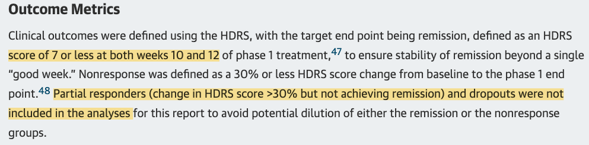

**McGrath et al., outcome definition (extremely biased).**

## Neglecting clinical information

### An imaging biomarker has to add information

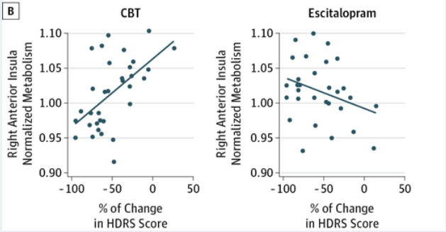

**McGrath et al. (2013), Figure 3B.** The interaction effect in the selected PET region.

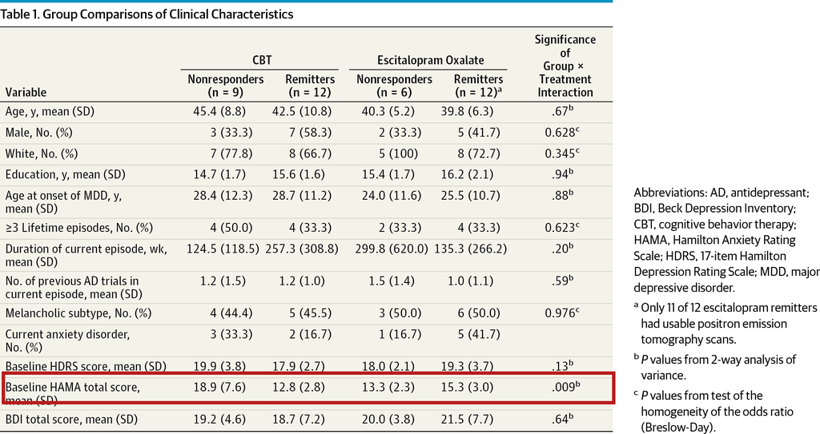

**McGrath et al., Table 1.** Baseline HAMA showed the same interaction (*P* = .009), suggesting clinical variables can explain the image association effect.

- This means controlling for relevant baseline measures
  - Same McGrath paper 👆
  - Including baseline values of the outcome when predicting future variables with imaging data

## Misleading uncertainty quantification

**Circular analysis and data leakage** Use components of the evaluation data for feature selection, preprocessing, or model tuning

- The model can appear to predict treatment response without having any real association
- **Barac et al. (2026):** Used the full dataset for feature selection.
  - They also didn’t control for baseline depression

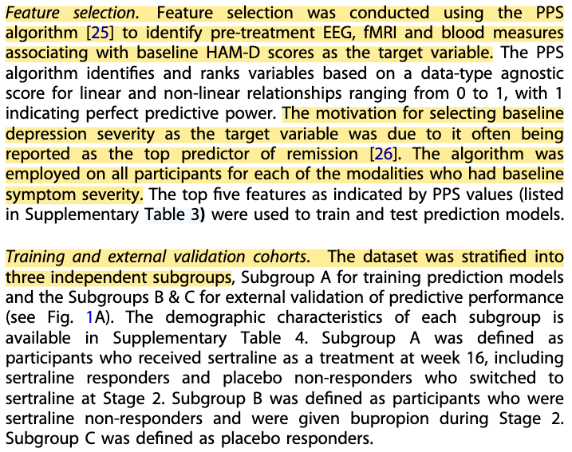

**Barac et al. (2026), feature selection.** Baseline depression severity was used as the target for selecting the top features before treatment-response prediction.

- Has the appearance of rigorous validation and strong prediction without actually doing it

# More examples in the paper

**Unreliability of Biomarker Research in Psychiatry**

Vandekar, S., Zhang, P., Patel. P.K., Jefferson, A.L., Harrell, F. (*under review*)

# Recommendations to improve replicability

**Most imaging biomarker studies that fail external validation would have failed rigorous internal validation**

- No longer just writing for humans
- Report effect sizes for all research results
- Specifying research goals *a priori*

## Stop writing like we are writing for humans

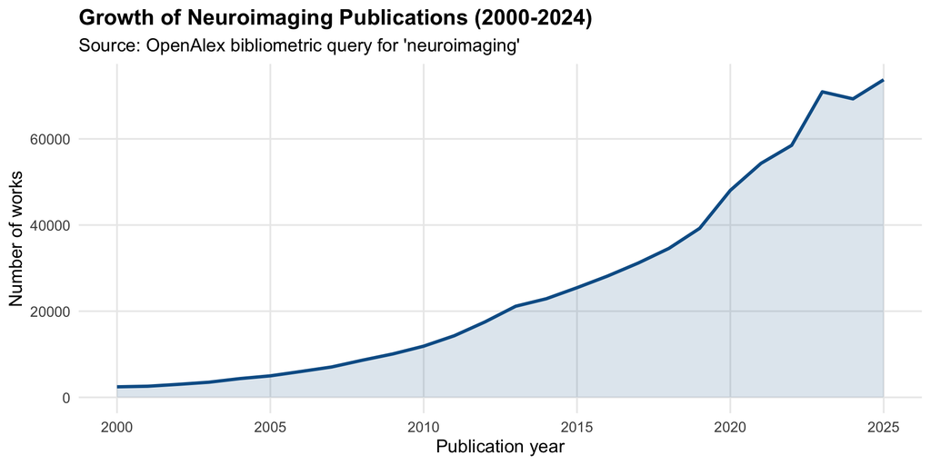

Figure 1

- Each study is single data point in an ocean of data
- Each paper is only useful insofar as it can contribute to a meta-analysis
- Evidence will be aggregated across studies by AI

## Quantitative reporting for AI

| Writing for humans | Writing for AI |
| --- | --- |
| Primary deliverable is interpretation | Primary deliverable is quantitative |
| Purpose is conceptual | Purpose is cumulative evidence synthesis |
| Statistics are complementary | Magnitude is quantified |
| Magnitude rarely discussed | Standardized effect sizes are reported consistently |

## Report effect sizes for all results

Bias comes from selective reporting

## When only the “significant” regions get reported

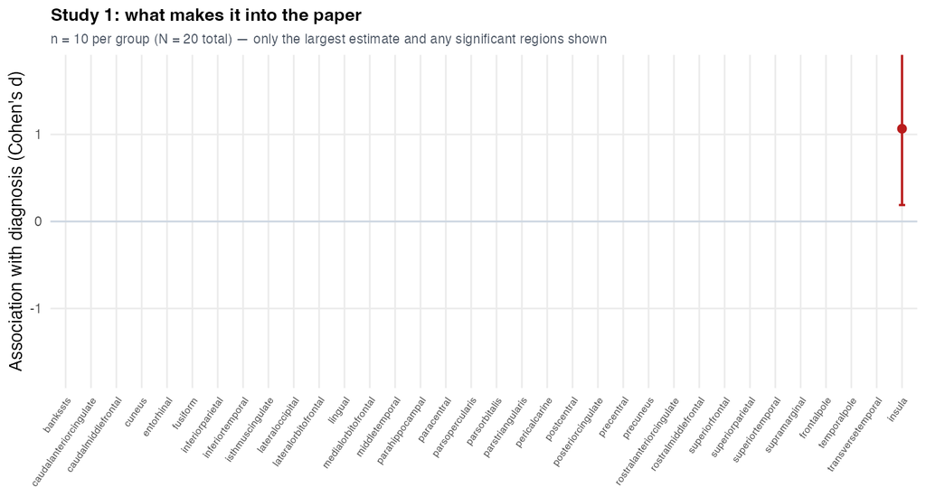

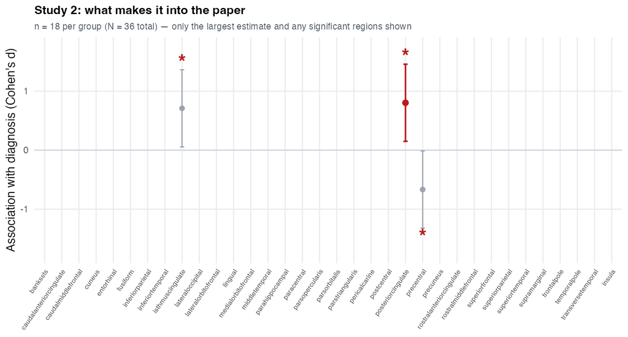

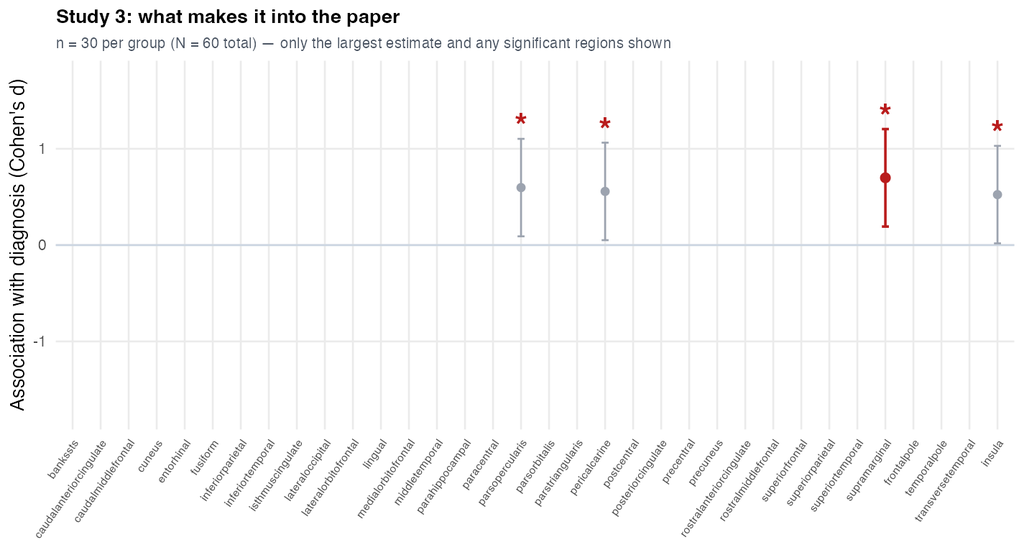

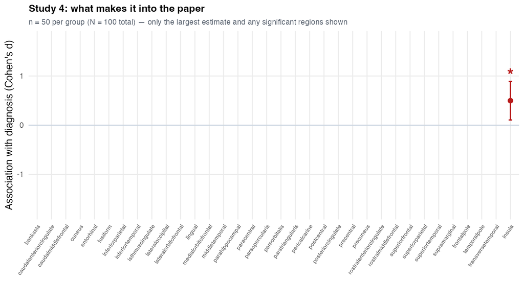

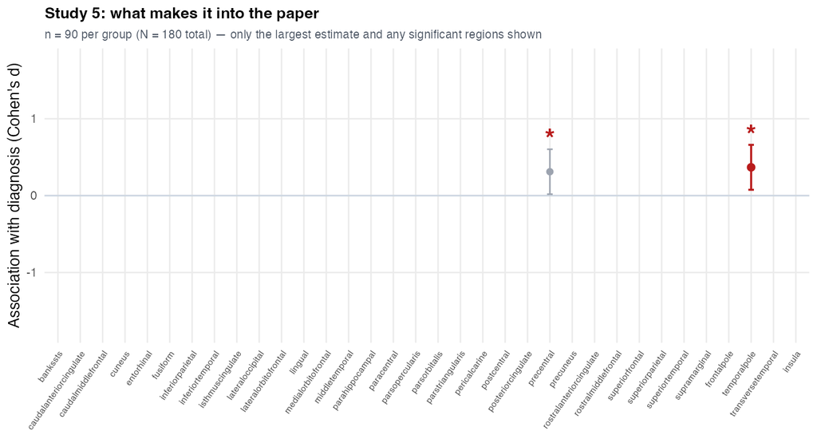

Red = the study's strongest association · **gray** = other significant regions · ★ = 95% CI excludes zero

- The effect size estimates are biased upward because they must be large enough to be significant
- Little shared information across datasets

## In truth each study held information about all results

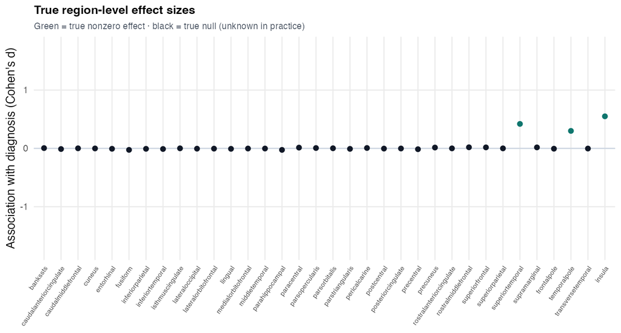

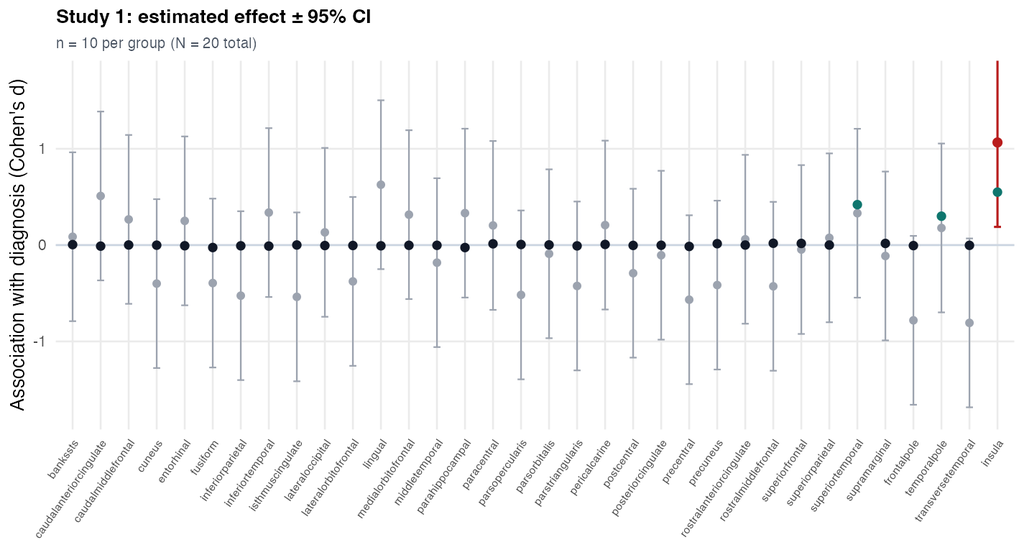

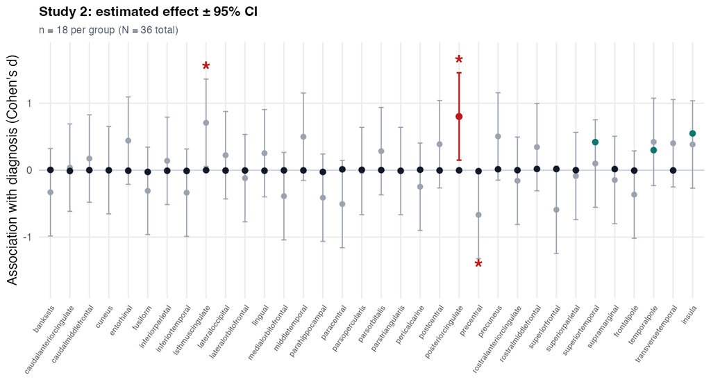

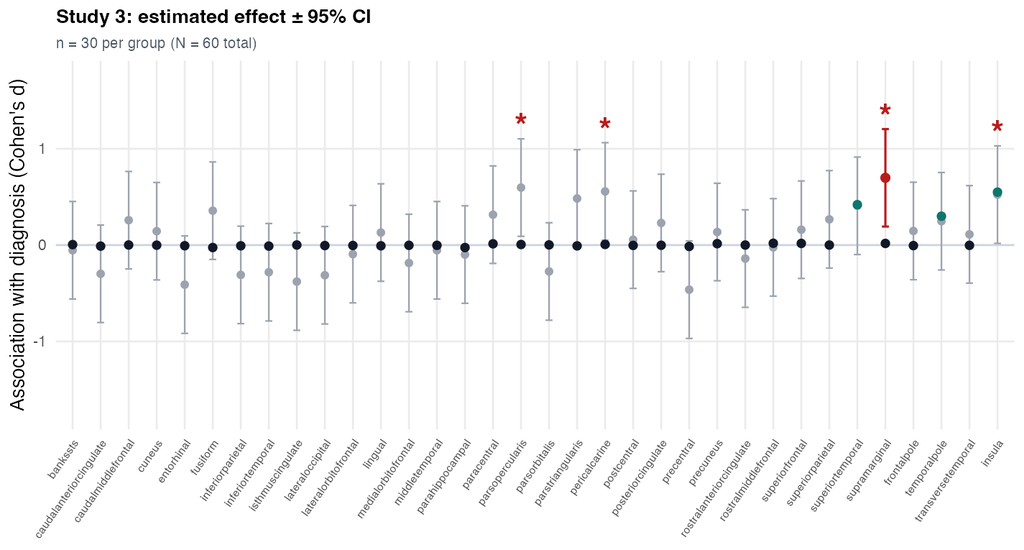

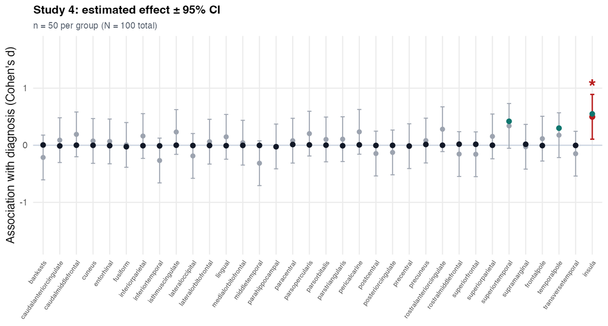

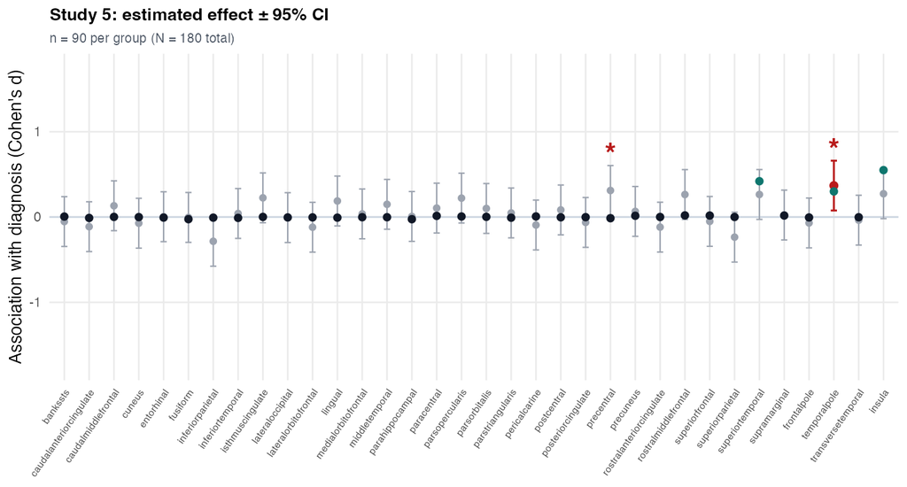

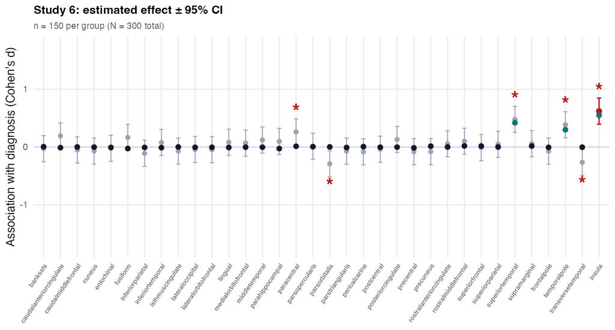

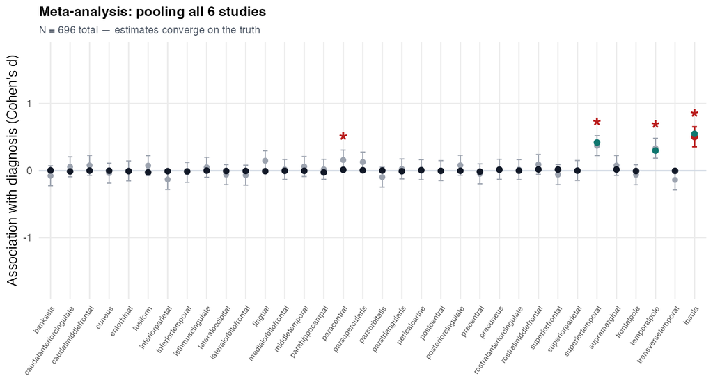

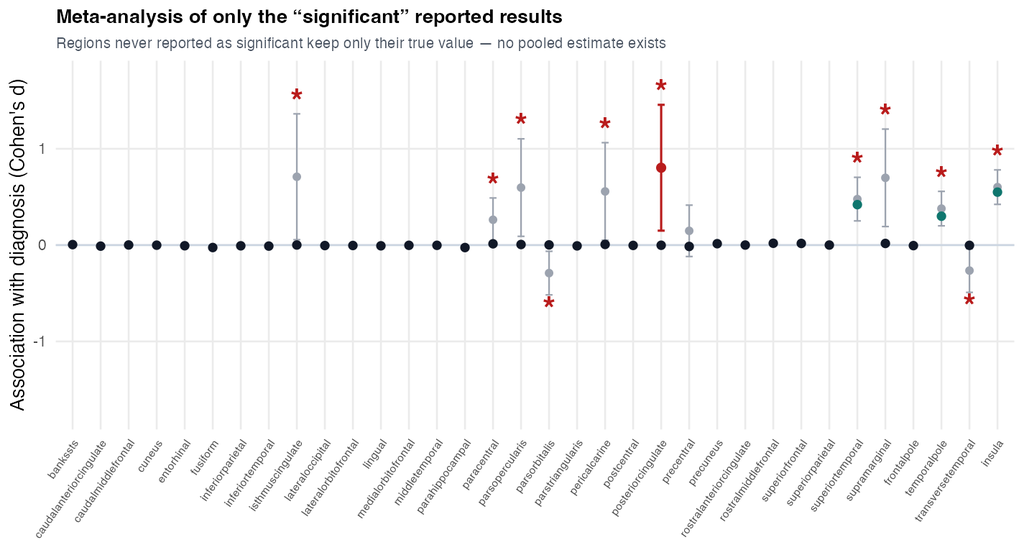

Green = true nonzero effect · **black** = true null · **gray** = study estimate ± 95% CI · red = the study's largest point estimate · ★ = 95% CI excludes zero

- Underpowered studies have wide, inconclusive CIs; larger studies converge on the truth and have greater precision
- Meta-analysis pooling all six studies recovers the true signal with a tight CI
- Meta-analysis based on biased reporting is also biased

## Reporting all results

- Counterintuitively: **bias is reduced when you report ALL your uncorrected exploratory analyses** (not just the significant ones)
- For neuroimaging - upload your unthresolded statistical images with useful metadata to [Neurovault](https://neurovault.org/)
- Include supplementary tables as PDF or online

### Specify research questions clearly *a priori*

- This will reduce repeated analyses to try to improve signal, which produces bias
- This should be specific enough that AI could take the instructions with the data and perform your analyses

# Standardized effect size are important

- They drive replicability
- They can be used for meta-analysis and power analysis

## Resolving challenges with reporting effect size estimates

Scientific question:  
e.g., X on Y in Z

?

Studies

Designs &  
hypotheses

Statistical  
analyses

Multiple GLM

Logistic

Two-group comparison

Simple GLM

Effect size

R² = 0.4 RESI = 0.13  
95% CI = (…)

OR = 1.2 RESI = 0.45  
95% CI = (…)

Cohen's d = 0.2 RESI = 0.1  
95% CI = (…)

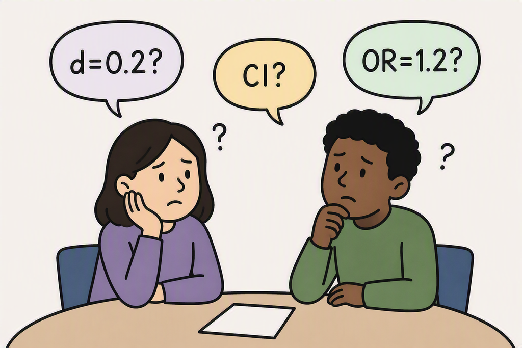

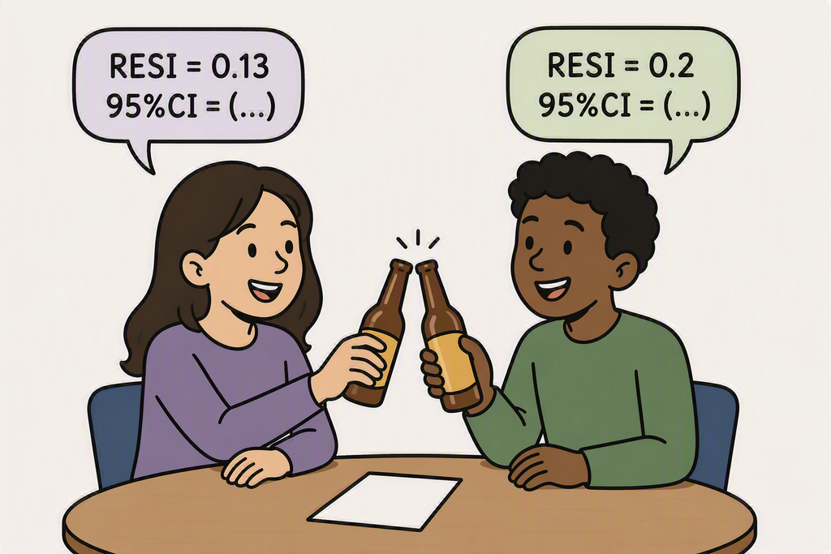

- Model-specific indices from different studies/designs can't be directly compared or synthesized
- Model-specific indices from different studies/designs can't be directly compared or synthesized
- It's hard to get confidence intervals for some of them
- We introduced a robust effect size index (RESI), a single, comparable effect size (with a CI) regardless model
- Enables direct comparison and meta-analysis across studies

# The robust effect size index (RESI)

[figure not shown]

- Interpreted on the same scale as Cohen’s $f$
- Signed version for regression coefficients, Unsigned version for more arbitrary effect sizes (all on the same scale)
- “Robust” in the sense that it is consistent
- Comes with a confidence interval
- Our papers on this are deriving/proving/validating the properties

| Effect size | Cohen’s $f$ |
| --- | --- |
| Small | 0.10 |
| Medium | 0.25 |
| Large | 0.40 |

## RESI R package

- Works directly on fitted model objects (`lm`, `glm`, `nls`, `coxph`, `lme`/`lmerMod`, and more)
- `resi()` returns effect sizes with confidence intervals

```r
library(RESI)
library(splines)
mod <- lm(charges ~ (ns(age, df=3) + ns(bmi, df=3)) * smoker + sex + region, data = insurance)
insRESI <- resi(mod)
av <- anova(insRESI)
knitr::kable(av, digits = c(0, 2, 3, 3, 3, 3))
```

|  | Df | F | Pr(>F) | RESI | 2.5% | 97.5% |
| --- | --- | --- | --- | --- | --- | --- |
| ns(age, df = 3) | 3 | 278.02 | 0.000 | 0.788 | 0.695 | 0.878 |
| ns(bmi, df = 3) | 3 | 152.30 | 0.000 | 0.582 | 0.505 | 0.660 |
| smoker | 1 | 5386.90 | 0.000 | 2.005 | 1.757 | 2.256 |
| sex | 1 | 4.07 | 0.044 | 0.048 | 0.000 | 0.109 |
| region | 3 | 4.22 | 0.006 | 0.085 | 0.028 | 0.144 |
| ns(age, df = 3):smoker | 3 | 0.47 | 0.703 | 0.000 | 0.000 | 0.069 |
| ns(bmi, df = 3):smoker | 3 | 394.84 | 0.000 | 0.939 | 0.785 | 1.086 |

- Every term gets a RESI and CI, directly comparable across models and studies

## Easy visualization

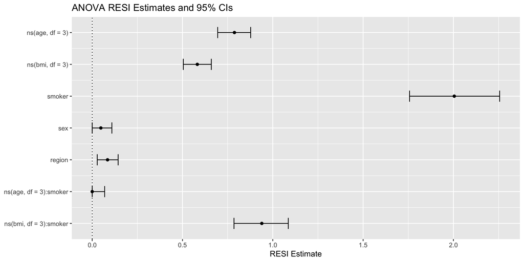

```r
library(ggplot2)
ggplot(av)
```

## Example interpretation/reporting

Report the test statistic, degrees of freedom, $p$-value, and effect size with its CI for every term, e.g.:

Smoking status had a very strong effect (F(1, 1320) = 5386.9, p < .001, RESI = 2, 95% CI [1.76, 2.26]).

The nonlinear age-by-smoking interaction was negligible (F(3, 1320) = 0.5, p = 0.703, RESI = 0, 95% CI [0, 0.07]) – the entire interval falls at or below Cohen’s small benchmark (0.10).

- The RESI and CI are directly comparable across models and different variables. $p$-values are not.

## Supplemental information to include

- In the supplement, include the full coefficient table with RESIs (or not)

```r
# example for RESI
# knitr::kable(coefficients(insRESI), digits = 3)
# or, for a manuscript-style regression table:
sjPlot::tab_model(mod, vcov.fun = sandwich::vcovHC)
```

|  | charges |  |  |
| --- | --- | --- | --- |
| Predictors | Estimates | CI | p |
| (Intercept) | 3220.76 | 1834.51 – 4607.01 | **<0.001** |
| age [1st degree] | 5842.19 | 4621.24 – 7063.14 | **<0.001** |
| age [2nd degree] | 12121.52 | 10144.31 – 14098.74 | **<0.001** |
| age [3rd degree] | 11157.45 | 10169.47 – 12145.44 | **<0.001** |
| bmi [1st degree] | 1251.68 | -60.95 – 2564.30 | 0.062 |
| bmi [2nd degree] | 1732.58 | -1400.95 – 4866.12 | 0.278 |
| bmi [3rd degree] | -891.19 | -2833.63 – 1051.25 | 0.368 |
| smoker | 12216.85 | 7886.19 – 16547.51 | **<0.001** |
| sex [male] | -519.96 | -1025.57 – -14.35 | **0.044** |
| region [northwest] | -383.37 | -1174.24 – 407.50 | 0.342 |
| region [southeast] | -994.77 | -1769.34 – -220.20 | **0.012** |
| region [southwest] | -1178.03 | -1882.75 – -473.30 | **0.001** |
| age [1st degree] × smoker | 784.04 | -2125.99 – 3694.08 | 0.597 |
| age [2nd degree] × smoker | 600.72 | -3291.05 – 4492.50 | 0.762 |
| age [3rd degree] × smoker | -941.56 | -2990.07 – 1106.96 | 0.367 |
| bmi [1st degree] × smoker | 34647.85 | 31191.83 – 38103.86 | **<0.001** |
| bmi [2nd degree] × smoker | 22494.46 | 10124.51 – 34864.41 | **<0.001** |
| bmi [3rd degree] × smoker | 22080.08 | 10486.83 – 33673.34 | **<0.001** |
| Observations | 1338 |  |  |
| R<sup>2</sup> / R<sup>2</sup> adjusted | 0.854 / 0.852 |  |  |

# Questions about statistical reporting?

- Ask [Simon Jr.](https://github.com/simonvandekar/simonvandekar.github.io/blob/main/manuscript-review-instructions.md) – a .md instruction file to review your papers
- Also, ask me!
  - I want help you do the best science possible.

# Thank you!

### NIH funding

- R01MH123563
- R01AG101908

[figure not shown]

These slides are on my website:  
simonvandekar.github.io/replicability.html

[figure not shown]

[figure not shown]

[statimagcoll.github.io/RESI](https://statimagcoll.github.io/RESI/)